# MLS 3302 Unit 1 Assignment 4: KEY

### Setup

Set working directory, your file path will be different, load required packages and data file.

```r
setwd("~/Box Sync/WSU/MLS3302_advpract/mls3302_unit1/unit1_assignments")
library(ggplot2)
library(psych)
mls3302_u1_assg4_dat <- read.csv("~/Box Sync/WSU/MLS3302_advpract/mls3302_unit1/unit1_assignments/mls3302_u1_assg4_dat.csv")
```

### Question 1

```r
describe(mls3302_u1_assg4_dat)
```

```
##       vars  n   mean    sd median trimmed   mad   min   max range  skew
## id       1 40  20.50 11.69  20.50   20.50 14.83   1.0  40.0  39.0  0.00
## chol     2 40 101.78 10.29  99.85  101.75  8.90  81.6 121.9  40.3  0.14
## vload    3 40 486.48 89.10 493.00  489.59 80.80 305.0 667.0 362.0 -0.27
##       kurtosis    se
## id       -1.29  1.85
## chol     -0.79  1.63
## vload    -0.55 14.09
```

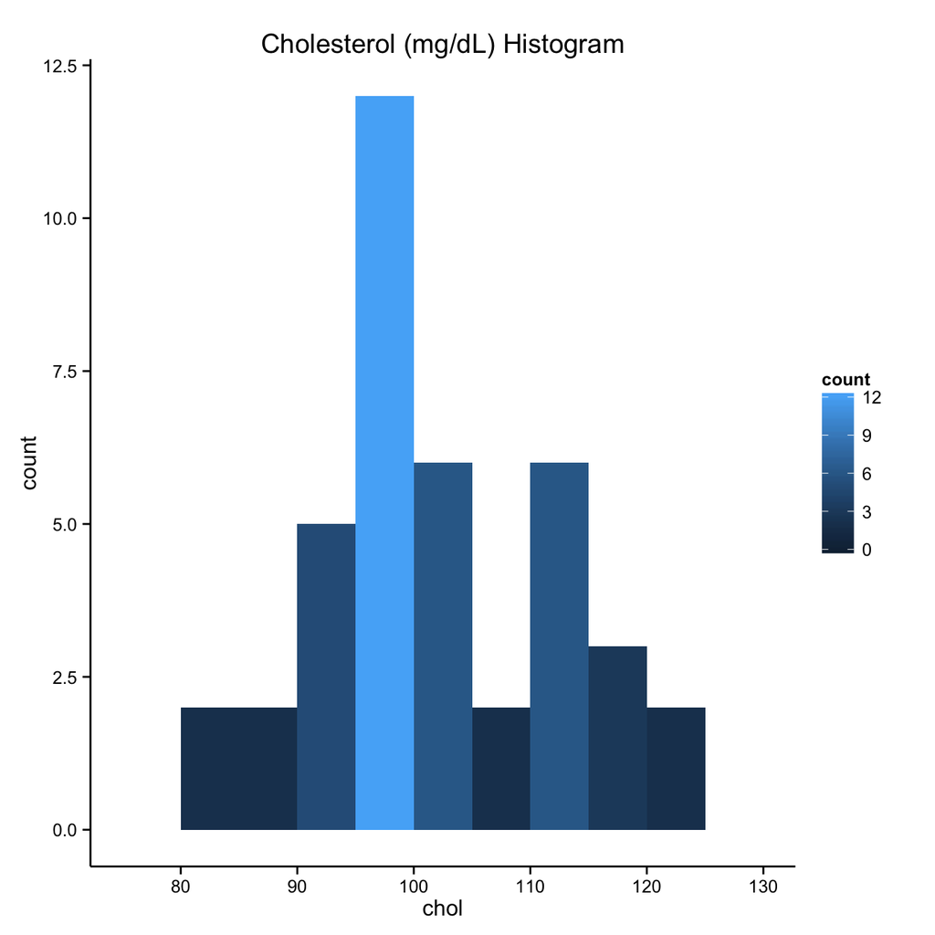

```r
chol_hist <- ggplot(data=mls3302_u1_assg4_dat, aes(x=chol)) + geom_histogram(binwidth=5, aes(fill=..count..)) + theme_classic() + labs(title="Cholesterol (mg/dL) Histogram")

vload_hist <- ggplot(data=mls3302_u1_assg4_dat, aes(x=vload)) + geom_histogram(binwidth=30, aes(fill=..count..)) + theme_classic() + labs(title="Viral Load (RNA copies/mL) Histogram")

chol_v_vload <- ggplot(data=mls3302_u1_assg4_dat, aes(x=vload, y=chol)) + geom_point(size=3, shape=18) + theme_classic() + labs(title="Cholesterol vs. Viral Load")
chol_hist
```

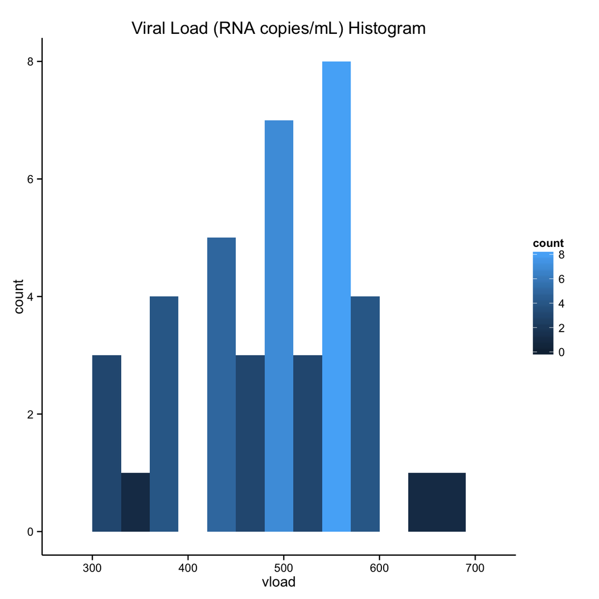

```r
vload_hist
```

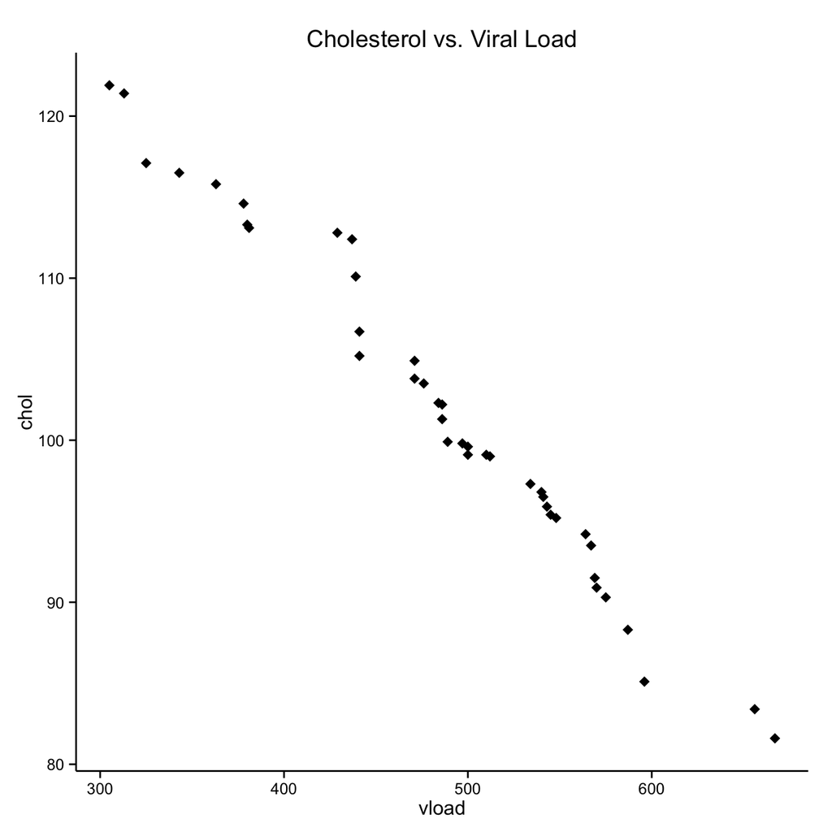

```r
chol_v_vload
```

**Conclusion**: The descriptive statistics and histograms are a good way to *get to know* the data, but are not serving any direct purpose for this assignment. That said, the histograms could reveal possible outlier points.

The scatter plot is the most important part of this first step.

- First it reveals there appears to be a **linear** relationship between cholesterol and viral load, an important assumption of linear regression is being met.
- Next, it also shows that these two variables have a strong negative correlation. Which I will test with the `cor()` function.

```r
cor(mls3302_u1_assg4_dat)
```

```
##               id       chol      vload
## id     1.0000000  0.9831074 -0.9740307
## chol   0.9831074  1.0000000 -0.9864994
## vload -0.9740307 -0.9864994  1.0000000
```

Cholesterol and Viral Load have a strong negative linear correlation (r = -0.9865).

### Question 2

Having observed a negative correlation between Cholesterol and Viral Load in Question 1, now we must quantify that relationship in more detail using a linear regression, `lm()` function.

```r
chol_v_vload_model <- lm(chol ~ vload, data=mls3302_u1_assg4_dat)
summary(chol_v_vload_model)
```

```
##
## Call:
## lm(formula = chol ~ vload, data = mls3302_u1_assg4_dat)
##
## Residuals:
##     Min      1Q  Median      3Q     Max
## -4.2008 -0.8067  0.0624  0.6430  4.9792
##
## Coefficients:
##               Estimate Std. Error t value Pr(>|t|)
## (Intercept) 157.222416   1.517201  103.63   <2e-16 ***
## vload        -0.113963   0.003069  -37.13   <2e-16 ***
## ---
## Signif. codes:  0 '***' 0.001 '**' 0.01 '*' 0.05 '.' 0.1 ' ' 1
##
## Residual standard error: 1.708 on 38 degrees of freedom
## Multiple R-squared:  0.9732, Adjusted R-squared:  0.9725
## F-statistic:  1379 on 1 and 38 DF,  p-value: < 2.2e-16
```

The important results of the regression analysis:

- t-Test if vload is a significant predictor of chol: p < 2.0x10<sup>-16</sup>
- F-Test if the *model* we specified is a significant predictor of chol: p < 2.0x10<sup>-16</sup>
- Regression Coefficients: Beta (slope) = -0.11396, Intercept = 157.22242
- Adjusted R-squared: 0.972

**t-Test: p < 2.0x10<sup>-16</sup>**: This t-Test is testing if the independent x variable (vload) is a significant predictor of the dependent y (chol) variable. The null is is that it is not a predictor and the alternative is that it is associated or a predictor of the y variable.

**F-Test: p < 2.0x10<sup>-16</sup>**: The F-Test is testing if the model is a significant predictor of the dependent variable, model being all the independent variables we are interested in as predictors. For this class, we will be performing univariate analysis, so the t-Test and F-Test should be approximately equal.

**Regression Coefficients**: Are the values of the slope (Beta) and intercept obtained from the regression analysis and used to quantify the relationship between x and y. As well as produce a regression equation. For the homework, the beta coefficient tells us that for every unit increase in vload, there is an associated decrease of -0.11396 mg/dL in chol. And the regression equation would be:

$$chol = -0.11396(vload) + 157.22242$$

**Adjusted R-squared: 0.972**: The R<sup>2</sup> gives a measure of how spread-out the points are from the regression line. If they lie directly on the line, R^2=1 (100%). The farther from the line the points are, the smaller the R<sup>2</sup>. We also can interpret the R<sup>2</sup> in context of the variation in y *explained* by x. For example: The vload explains about 97% of the variation in cholesterol levels seen in this study.

**Conclusion**: The results of the regression analysis show that viral load is significantly associated with cholesterol levels (p < 2.0x10<sup>16</sup>). The viral load seems to explain about 97% of the variation in cholesterol levels, so overall our model is a good fit. The regression coefficients tell us that for every one increase in HIV viral load (copies/mL) there is an associated decrease of 0.11396 mg/dL in cholesterol levels.

It is always good to show a plot of the points with the fitted regression line.

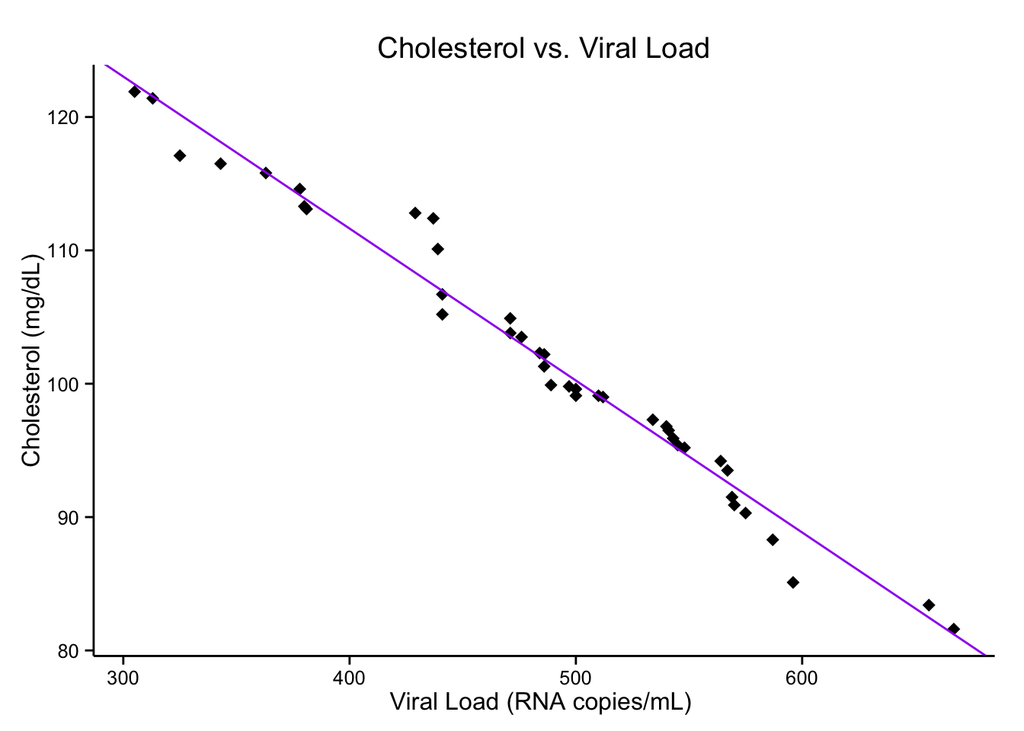

```r
chol_v_vload_regp <- ggplot(data=mls3302_u1_assg4_dat, aes(x=vload, y=chol)) + geom_point(size=3, shape=18) + theme_classic() + labs(title="Cholesterol vs. Viral Load", y="Cholesterol (mg/dL)", x="Viral Load (RNA copies/mL) ") + geom_abline(intercept=157.22242, slop=-0.11396, colour='purple')
chol_v_vload_regp
```

### Question 3

**Regression Equation**:

$$Cholesterol = -0.11396(Viral Load) + 157.22242$$

If a patient had a Viral Load = 57 RNA copies/mL then:

```r
-0.11396*57 + 157.22242
```

```
## [1] 150.7267
```

We would predict their cholesterol level to be 150.7 mg/dL

### Bonus

**Residual Plot**: The residual plot takes the residuals (actual dependent variable values - predicted dependent variable values) on the y-axis and plots them for every value of the dependent variable placed on the x-axis.

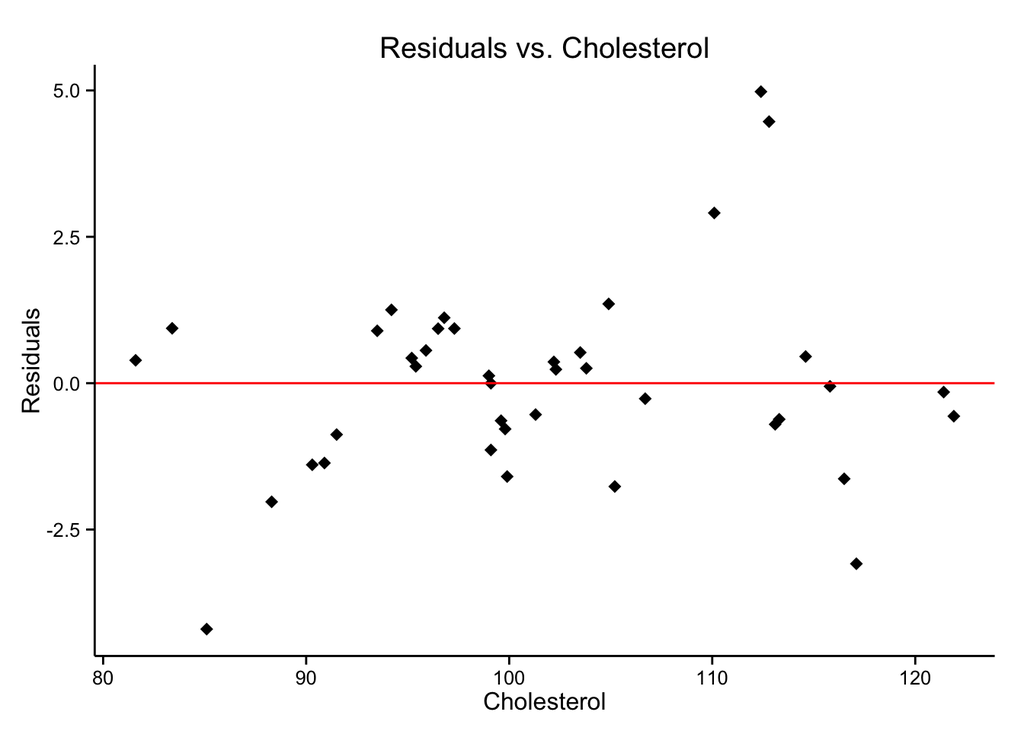

```r
model_resid <- resid(chol_v_vload_model)
resid_plot <- ggplot(data=mls3302_u1_assg4_dat, aes(x=chol, y=model_resid)) + geom_point(size=3, shape=18) + theme_classic() + geom_abline(intercept=0, slope=0, colour='red') + labs(title='Residuals vs. Cholesterol', y='Residuals', x='Cholesterol')
resid_plot
```

**Conclusion**: The residuals appear to be randomly spread around the zero line. That is, there appears to be no pattern to their distribution around the zero line. This supports our assumption of homescedasticity of the residuals.